# Project

Wiktoria Kowalska, Emilia Lehmann

2026-11-22

W projekcie zostały wykorzystane biblioteki:

```r
library(readr)
library(corrplot)
library(dplyr)
library(psych)
library(tidyr)
library(factoextra)
```

# 1. Opis danych i przygotowanie ramki danych.

Wybrane dane pochodzą ze zbioru “Football Teams” (z platformy Kaggle) i mają charakter przekrojowy, opisując statystyki meczowe oraz ogólną ocenę gry 98 europejskich drużyn piłkarskich z pięciu czołowych lig.

Link do zbioru danych:

https://www.kaggle.com/datasets/varpit94/football-teams-rankings-stats

**Druzyna** - Team: nazwa klubu piłkarskiego (character / tekstowa).

**Liga** - Tournament: nazwa ligi krajowej, w której występuje drużyna (character / tekstowa).

**Bramki** - Goals: łączna liczba bramek zdobytych przez drużynę w sezonie (integer / całkowita, w szt.).

**Strzaly_na_mecz** - Shots pg: średnia liczba strzałów oddawanych przez drużynę w jednym meczu (numeric / zmiennoprzecinkowa, w szt.).

**Zolte_kartki** - yellow_cards: łączna liczba żółtych kartek otrzymanych przez zawodników drużyny w sezonie (integer / całkowita, w szt.).

**Czerwone_kartki** - red_cards: łączna liczba czerwonych kartek otrzymanych przez zawodników drużyny w sezonie (integer / całkowita, w szt.).

**Posiadanie_pilki** - Possession%: średni procentowy czas posiadania piłki przez drużynę w trakcie meczu (numeric / zmiennoprzecinkowa, w %).

**Celne_podania** - Pass%: odsetek celnych podań wykonanych przez drużynę (numeric / zmiennoprzecinkowa, w %).

**Wygrane_pojedynki_powietrzne** - AerialsWon: średnia liczba wygranych pojedynków główkowych przez drużynę na mecz (numeric / zmiennoprzecinkowa, w szt.).

**Ocena** - Rating: ogólna ocena punktowa jakości gry drużyny (numeric / zmiennoprzecinkowa, w pkt).

```r
data <- read_csv("Football_teams.csv")
View(data)

data <- na.omit(data)
colnames(data) <- c(
  "Druzyna",
  "Liga",
  "Bramki",
  "Strzaly_na_mecz",
  "Zolte_kartki",
  "Czerwone_kartki",
  "Posiadanie_pilki",
  "Celne_podania",
  "Wygrane_pojedynki_powietrzne",
  "Ocena"
)

data
```

```
## # A tibble: 98 × 10
##    Druzyna             Liga  Bramki Strzaly_na_mecz Zolte_kartki Czerwone_kartki
##    <chr>               <chr>  <dbl>           <dbl>        <dbl>           <dbl>
##  1 Manchester City     Prem…     83            15.8           46               2
##  2 Bayern Munich       Bund…     99            17.1           44               3
##  3 Paris Saint-Germain Ligu…     86            15             73               7
##  4 Barcelona           LaLi…     85            15.3           68               2
##  5 Real Madrid         LaLi…     67            14.4           57               2
##  6 Manchester United   Prem…     73            13.8           64               1
##  7 Juventus            Seri…     77            15.7           76               6
##  8 Aston Villa         Prem…     55            13.7           63               4
##  9 Borussia Dortmund   Bund…     75            14.6           43               1
## 10 Atletico Madrid     LaLi…     67            12.1          100               0
## # ℹ 88 more rows
## # ℹ 4 more variables: Posiadanie_pilki <dbl>, Celne_podania <dbl>,
## #   Wygrane_pojedynki_powietrzne <dbl>, Ocena <dbl>
```

```r
nrow(data)
```

```
## [1] 98
```

W zbiorze Football teams.csv jest 98 drużyn i 0 braków danych (NA) – po na.omit(data) nadal zostaje 98 obserwacji.

# 2. EDA.

Przed przystąpieniem do redukcji wymiarów wyznaczamy podstawowe statystyki dla analizowanych zmiennych ilościowych, a następnie zbadamy siłę i kierunek zależności liniowych między nimi za pomocą macierzy korelacji Pearsona. Ze względu na różne jednostki pomiarowe (m.in. liczba bramek w sezonie, procent posiadania piłki, średnia liczba strzałów na mecz) konieczna będzie późniejsza standaryzacja danych.

Podstawowe statystyki opisowe zmiennych.

```r
summary(data)
```

```
##    Druzyna              Liga               Bramki      Strzaly_na_mecz
##  Length:98          Length:98          Min.   :20.00   Min.   : 7.10
##  Class :character   Class :character   1st Qu.:40.25   1st Qu.:10.32
##  Mode  :character   Mode  :character   Median :50.00   Median :11.45
##                                        Mean   :52.18   Mean   :11.85
##                                        3rd Qu.:61.75   3rd Qu.:13.35
##                                        Max.   :99.00   Max.   :17.10
##   Zolte_kartki   Czerwone_kartki  Posiadanie_pilki Celne_podania
##  Min.   : 40.0   Min.   : 0.000   Min.   :38.50    Min.   :66.50
##  1st Qu.: 60.0   1st Qu.: 2.000   1st Qu.:46.23    1st Qu.:78.03
##  Median : 67.5   Median : 3.000   Median :49.75    Median :80.80
##  Mean   : 69.7   Mean   : 3.337   Mean   :50.00    Mean   :80.44
##  3rd Qu.: 80.0   3rd Qu.: 4.750   3rd Qu.:52.85    3rd Qu.:83.45
##  Max.   :117.0   Max.   :10.000   Max.   :62.40    Max.   :89.70
##  Wygrane_pojedynki_powietrzne     Ocena
##  Min.   : 9.50                Min.   :6.410
##  1st Qu.:14.03                1st Qu.:6.540
##  Median :16.10                Median :6.630
##  Mean   :16.01                Mean   :6.646
##  3rd Qu.:17.85                3rd Qu.:6.730
##  Max.   :26.80                Max.   :7.010
```

```r
describe(data)
```

```
##                              vars  n  mean    sd median trimmed   mad   min
## Druzyna*                        1 98 49.50 28.43  49.50   49.50 36.32  1.00
## Liga*                           2 98  3.04  1.41   3.00    3.05  1.48  1.00
## Bramki                          3 98 52.18 16.45  50.00   51.14 14.83 20.00
## Strzaly_na_mecz                 4 98 11.85  2.15  11.45   11.73  2.00  7.10
## Zolte_kartki                    5 98 69.70 15.14  67.50   69.12 14.08 40.00
## Czerwone_kartki                 6 98  3.34  2.15   3.00    3.17  1.48  0.00
## Posiadanie_pilki                7 98 50.00  4.89  49.75   49.82  5.11 38.50
## Celne_podania                   8 98 80.44  4.69  80.80   80.67  4.00 66.50
## Wygrane_pojedynki_powietrzne    9 98 16.01  3.08  16.10   15.84  2.74  9.50
## Ocena                          10 98  6.65  0.13   6.63    6.64  0.15  6.41
##                                 max range  skew kurtosis   se
## Druzyna*                      98.00  97.0  0.00    -1.24 2.87
## Liga*                          5.00   4.0 -0.03    -1.31 0.14
## Bramki                        99.00  79.0  0.58    -0.08 1.66
## Strzaly_na_mecz               17.10  10.0  0.48    -0.39 0.22
## Zolte_kartki                 117.00  77.0  0.45    -0.06 1.53
## Czerwone_kartki               10.00  10.0  0.71     0.28 0.22
## Posiadanie_pilki              62.40  23.9  0.29    -0.42 0.49
## Celne_podania                 89.70  23.2 -0.48     0.24 0.47
## Wygrane_pojedynki_powietrzne  26.80  17.3  0.67     1.07 0.31
## Ocena                          7.01   0.6  0.42    -0.59 0.01
```

Korelacje

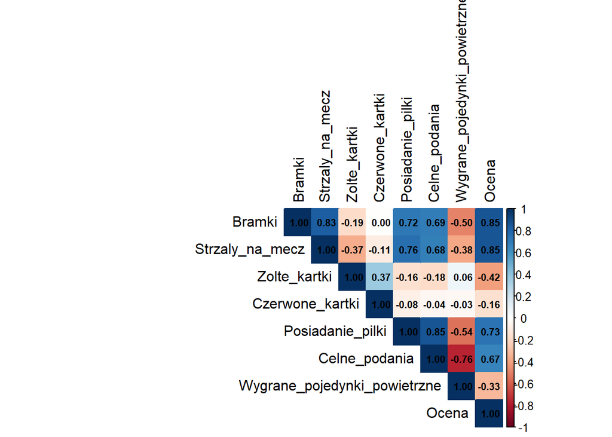

```r
data <- as.data.frame(data)
rownames(data) <- data$Druzyna

data_clean <- data %>%
  select(-c(Druzyna, Liga))

macierz_korelacji <- cor(data_clean, use = "pairwise.complete.obs")

corrplot(macierz_korelacji, method = "color", type = "upper",
         addCoef.col = "black", tl.col = "black", number.cex = 0.7)
```

# 3. PCA.

Standaryzowane korelacje:

```r
pca <- prcomp(data_clean, scale. = TRUE)
pca
```

```
## Standard deviations (1, .., p=8):
## [1] 2.1297226 1.1859899 0.9129464 0.7721454 0.5524834 0.3916708 0.3110871
## [8] 0.2694643
##
## Rotation (n x k) = (8 x 8):
##                                      PC1         PC2          PC3         PC4
## Bramki                       -0.41799856 -0.07722417 -0.265096117 -0.13171399
## Strzaly_na_mecz              -0.42153367  0.09574283 -0.292590163 -0.06285530
## Zolte_kartki                  0.16857672 -0.62531260  0.002042618 -0.72546065
## Czerwone_kartki               0.06182813 -0.64127752 -0.512385562  0.54827074
## Posiadanie_pilki             -0.41854847 -0.10803257  0.056341082 -0.20695834
## Celne_podania                -0.41805131 -0.18893908  0.299480063  0.05866869
## Wygrane_pojedynki_powietrzne  0.30003557  0.32815957 -0.622930526 -0.31173238
## Ocena                        -0.41877760  0.16600999 -0.317280384 -0.09141025
##                                      PC5         PC6          PC7         PC8
## Bramki                        0.55282359  0.15936468 -0.403150682 -0.48800370
## Strzaly_na_mecz               0.01963775 -0.81405327  0.229464456  0.08865991
## Zolte_kartki                  0.10487735 -0.04324112  0.167417887  0.11563268
## Czerwone_kartki              -0.13926912  0.03379640 -0.003842579  0.03532430
## Posiadanie_pilki             -0.64621552  0.04018479 -0.569768329  0.15262637
## Celne_podania                -0.29195655  0.17448523  0.554687194 -0.52253536
## Wygrane_pojedynki_powietrzne -0.38516242  0.11230170  0.112294250 -0.37881219
## Ocena                         0.11145439  0.51403949  0.334437209  0.54729918
```

Sprawdzenie czy PCA ma sens:

```r
R<- cor(data_clean)

cortest.bartlett(R, n = nrow(data_clean))
```

```
## $chisq
## [1] 641.9258
##
## $p.value
## [1] 2.600901e-117
##
## $df
## [1] 28
```

P-value wychodzi mniejsze niż 5%, więc odrzucamy H0 o tym, że macierz korelacji jest macierzą jednostkową — zmienne są ze sobą istotnie skorelowane.

```r
KMO(R)
```

```
## Kaiser-Meyer-Olkin factor adequacy
## Call: KMO(r = R)
## Overall MSA =  0.76
## MSA for each item =
##                       Bramki              Strzaly_na_mecz
##                         0.76                         0.89
##                 Zolte_kartki              Czerwone_kartki
##                         0.52                         0.61
##             Posiadanie_pilki                Celne_podania
##                         0.84                         0.75
## Wygrane_pojedynki_powietrzne                        Ocena
##                         0.62                         0.77
```

Wynik ogólny MSA jest większy niż 0.5 (*Overall MSA*= 0.76), więc zmienne mają wystarczająco dużo wspólnej wariancji, aby PCA miało sens.

```r
lambda <- pca$sdev^2

cumsum(lambda) / sum(lambda) * 100
```

```
## [1]  56.69648  74.27863  84.69702  92.14962  95.96510  97.88267  99.09236
## [8] 100.00000
```

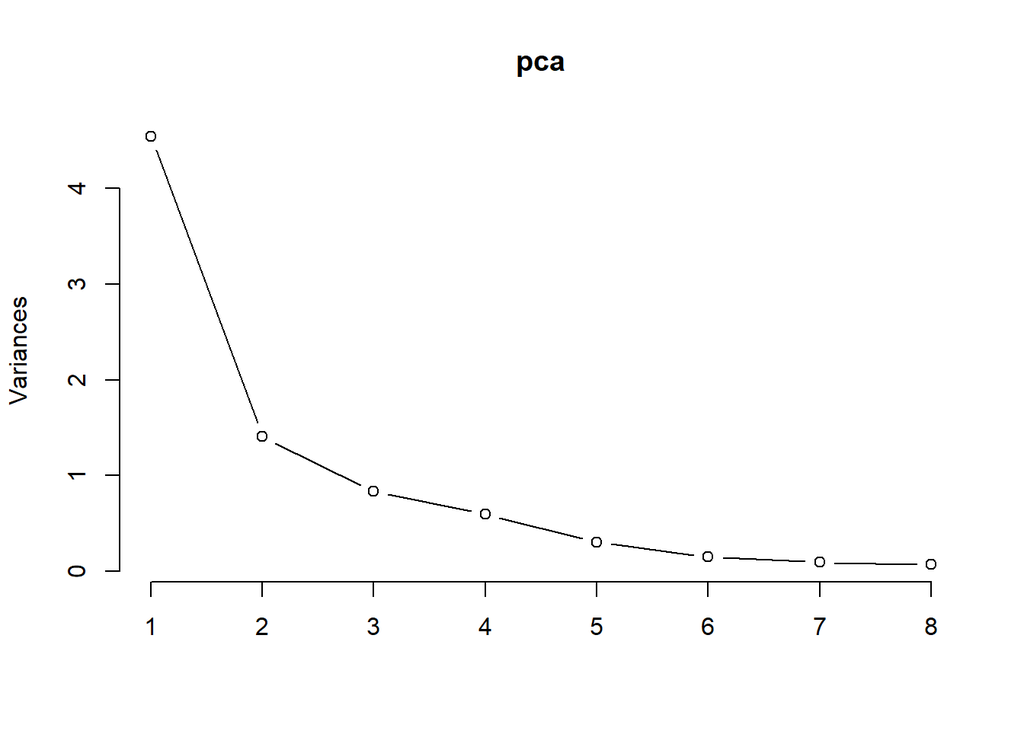

```r
screeplot(pca, type = "lines")
```

```r
summary(pca)
```

```
## Importance of components:
##                          PC1    PC2    PC3     PC4     PC5     PC6    PC7
## Standard deviation     2.130 1.1860 0.9129 0.77215 0.55248 0.39167 0.3111
## Proportion of Variance 0.567 0.1758 0.1042 0.07453 0.03815 0.01918 0.0121
## Cumulative Proportion  0.567 0.7428 0.8470 0.92150 0.95965 0.97883 0.9909
##                            PC8
## Standard deviation     0.26946
## Proportion of Variance 0.00908
## Cumulative Proportion  1.00000
```

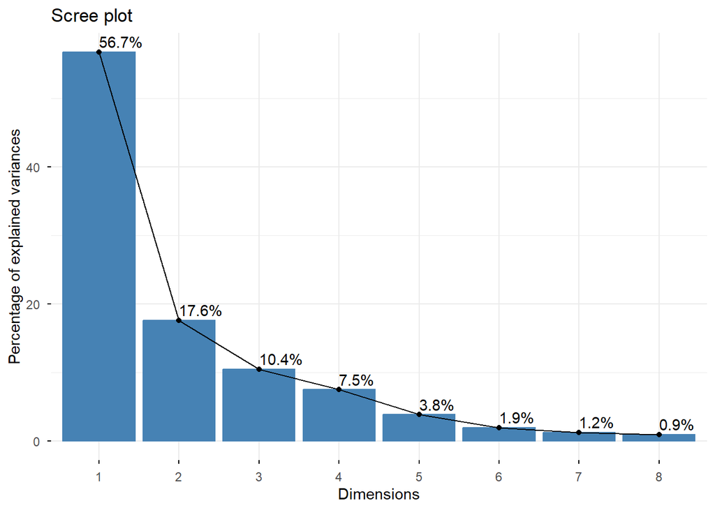

```r
fviz_eig(pca, addlabels = TRUE)
```

```r
pca$rotation
```

```
##                                      PC1         PC2          PC3         PC4
## Bramki                       -0.41799856 -0.07722417 -0.265096117 -0.13171399
## Strzaly_na_mecz              -0.42153367  0.09574283 -0.292590163 -0.06285530
## Zolte_kartki                  0.16857672 -0.62531260  0.002042618 -0.72546065
## Czerwone_kartki               0.06182813 -0.64127752 -0.512385562  0.54827074
## Posiadanie_pilki             -0.41854847 -0.10803257  0.056341082 -0.20695834
## Celne_podania                -0.41805131 -0.18893908  0.299480063  0.05866869
## Wygrane_pojedynki_powietrzne  0.30003557  0.32815957 -0.622930526 -0.31173238
## Ocena                        -0.41877760  0.16600999 -0.317280384 -0.09141025
##                                      PC5         PC6          PC7         PC8
## Bramki                        0.55282359  0.15936468 -0.403150682 -0.48800370
## Strzaly_na_mecz               0.01963775 -0.81405327  0.229464456  0.08865991
## Zolte_kartki                  0.10487735 -0.04324112  0.167417887  0.11563268
## Czerwone_kartki              -0.13926912  0.03379640 -0.003842579  0.03532430
## Posiadanie_pilki             -0.64621552  0.04018479 -0.569768329  0.15262637
## Celne_podania                -0.29195655  0.17448523  0.554687194 -0.52253536
## Wygrane_pojedynki_powietrzne -0.38516242  0.11230170  0.112294250 -0.37881219
## Ocena                         0.11145439  0.51403949  0.334437209  0.54729918
```

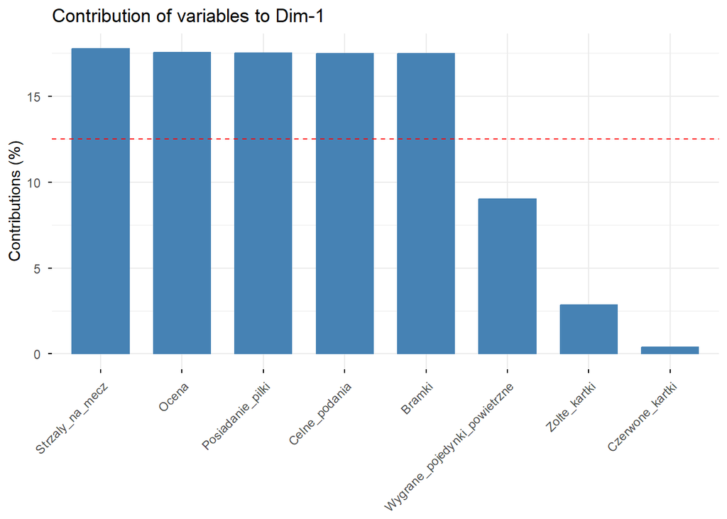

```r
fviz_contrib(pca, choice = "var", axes = 1)
```

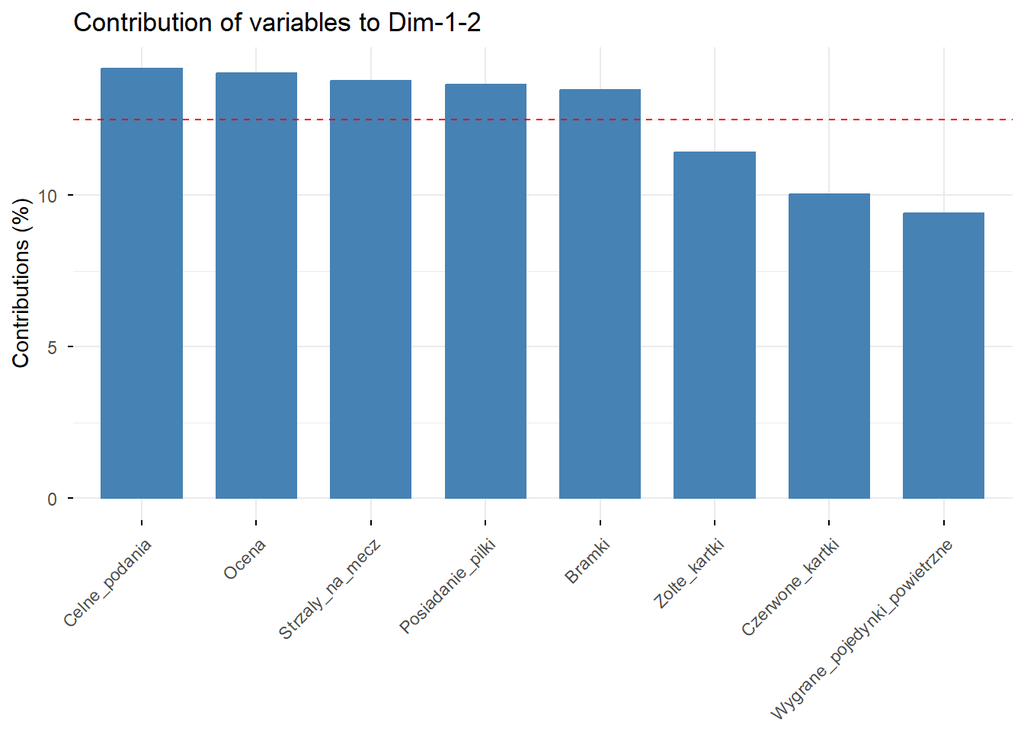

```r
fviz_contrib(pca, choice = "var", axes = 1:2)
```

```r
cor(data_clean, pca$x[, 1:2])
```

```
##                                     PC1         PC2
## Bramki                       -0.8902210 -0.09158708
## Strzaly_na_mecz              -0.8977498  0.11355003
## Zolte_kartki                  0.3590216 -0.74161440
## Czerwone_kartki               0.1316768 -0.76054863
## Posiadanie_pilki             -0.8913921 -0.12812554
## Celne_podania                -0.8903333 -0.22407983
## Wygrane_pojedynki_powietrzne  0.6389925  0.38919392
## Ocena                        -0.8918801  0.19688617
```

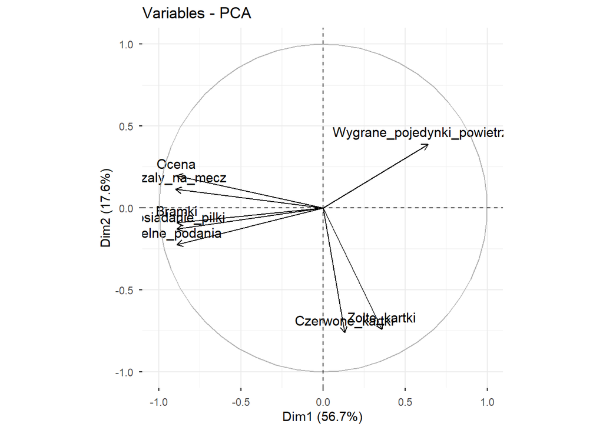

```r
fviz_pca_var(pca)
```

```r
cor(data_clean, pca$x[, 1:4])^2
```

```
##                                     PC1         PC2          PC3         PC4
## Bramki                       0.79249339 0.008388193 5.857297e-02 0.010343368
## Strzaly_na_mecz              0.80595469 0.012893609 7.135263e-02 0.002355494
## Zolte_kartki                 0.12889654 0.549991923 3.477480e-06 0.313780468
## Czerwone_kartki              0.01733877 0.578434223 2.188186e-01 0.179220765
## Posiadanie_pilki             0.79457993 0.016416153 2.645702e-03 0.025536658
## Celne_podania                0.79269340 0.050211770 7.475261e-02 0.002052159
## Wygrane_pojedynki_powietrzne 0.40831145 0.151471904 3.234221e-01 0.057937804
## Ocena                        0.79545016 0.038764163 8.390290e-02 0.004981819
```

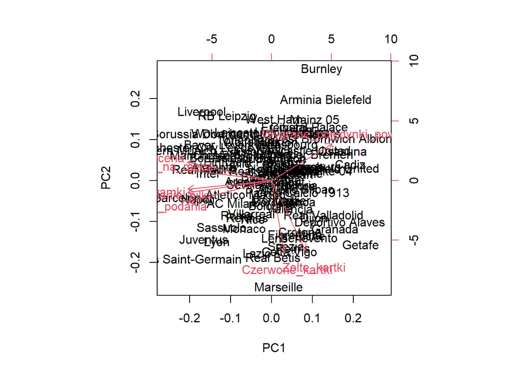

```r
biplot(pca)
```